# The Invisible Bias

Reading Your Fits · Module 5

## Predict first

You fit a straight line to lab data. Then one sensor gets noisier.

- If the **y** sensor gets noisier, the fitted slope will… get steeper? flatter? stay the same?
- If the **x** sensor gets noisier, the fitted slope will… ?

## Noise in y costs precision. Noise in x costs accuracy.

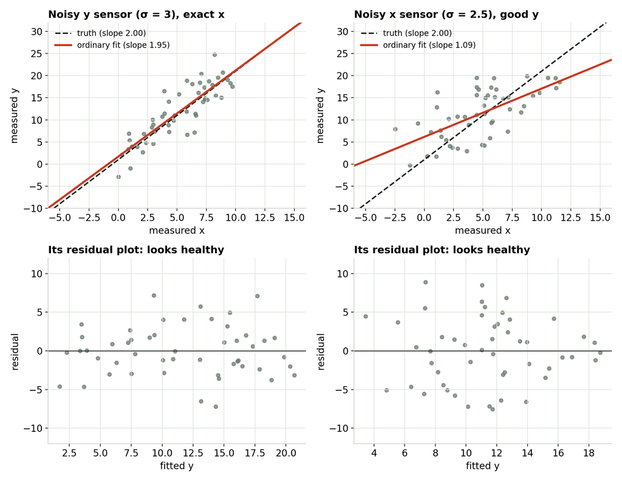

## Why the residual plot can’t warn you

- A least-squares fit tilts itself until the leftovers are **balanced against x**.
- So whatever error is tangled up with x gets absorbed into the slope, not left in the residuals.
- A residual plot can only show what the fit **didn’t** absorb.

You catch this problem by asking how the data was produced, not by looking at the leftovers.

## How much does the slope shrink?

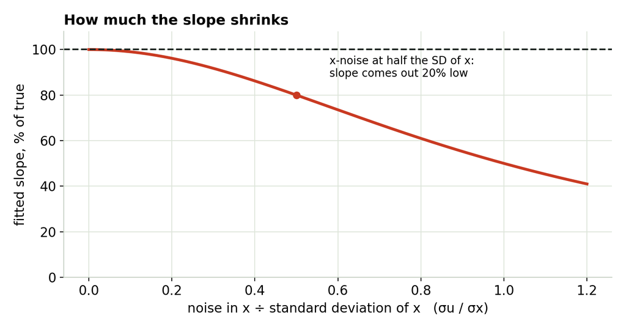

**Rule of thumb:** compare the x sensor’s error with the **standard deviation** of your x values (about 2.9 for x spread evenly over 0 to 10, not the range of 10). At a ratio of 0.3 the slope is about 8% low; at 0.5, 20% low; at 1, half.

## Will more data fix it? No.

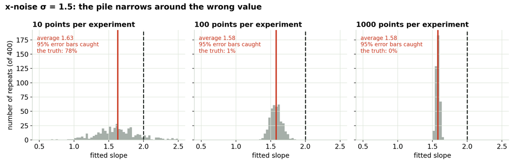

The pile gets narrower around **1.58**, not 2.00. At 1000 points the software’s 95% error bars never contain the truth.

## Something you didn’t measure

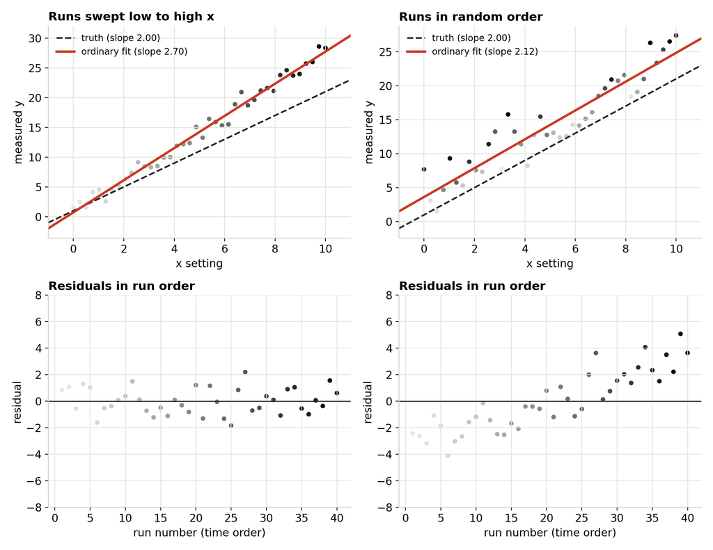

## Randomize the run order

- Sweeping x low → high ties **anything that changes with time** to x.
- Randomizing doesn’t remove drift. It makes it **harmless** (not in the slope) and **visible** (a trend in run order).
- Also log what might drift: ambient temperature, supply voltage, time since power-on.

## What actually fixes noise in x

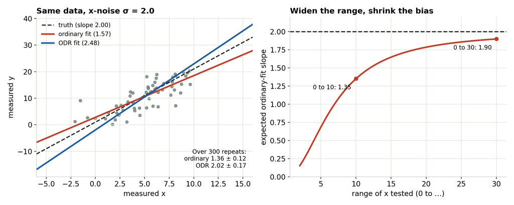

- **Errors-in-x fit** (orthogonal distance / Deming): removes the bias, but needs each sensor’s noise level and wobbles more.
- **Test over a wider range:** the same noise matters less when x varies more.

## Try it yourself

[interactive chart not shown]

The interactive loads from the page next to these slides. Open it in its own tab.

## Three questions to ask about any fit

### Is x really exact?

Compare the x sensor’s error with the standard deviation of your x values. More than about a third of it? Expect the slope 10% or more too flat.

### What changed during the session?

Temperature, supply voltage, warm-up, wear. If it moves with x, it hides inside your slope.

### Does y push back on x?

In closed-loop tests a controller sets x from y, so they’re tangled by design.

## The name for this

**Endogeneity:** the error in y is related to x. The slope is wrong, more data doesn’t help, and the residual plot hides it.

**Heteroskedasticity** is a different problem: uneven scatter. It **does** show in the residual plot (a fan shape), and the slope stays right; only the error bars are off.

Uneven scatter has its own module (Module 3). Next: Module 6, using and reporting a fit.